# **Assignment 01: Tell a Data Story** (draft)

Boston Food Establishment Inspections Dataset

Juan Cruz Ferreyra

```r
library(tidyverse)
library(sf)
library(ggmap)
library(tmap)
library(tmaptools)
library(osmdata)
library(kableExtra)
library(rlang)
```

```r
perc_adjuster <- function(df) {
  if(sum(df$perc)!=1){
    difference <- sum(df$perc) - 1
    if(length(df$perc)>=3) {
      df[3,"perc"] <- df[3,"perc"] - difference
    } else {
      df[1,"perc"] <- df[1,"perc"] - difference
    }
  }
  return(df)
}


calculate_sep <- function(ymax) {
  multiples <- c(0.01, 0.02, 0.05, 0.1)

  options <- plyr::round_any(ymax/4, multiples)
  sep <- options[max(which(ymax %/% options < 10))]

  return(sep)
}


calculate_lim <- function(ymax, sep) {
  remainder <- ymax %% sep
  if (remainder / sep > .75 ) {
    n_sep <- ((ymax %/% sep) + 2)
  } else {
    n_sep <- ((ymax %/% sep) + 1)
  }

  return(min(1, n_sep * sep))
}


plot_single_count <- function(
    df,
    column,
    title=NULL,
    subtitle=NULL,
    t_size=10,
    same_size=FALSE,
    xtext=NULL,
    ymax=NULL,
    fill="#fdae61",
    orient="v",
    m=c(10, 5, 0, 5),
    aspect_ratio=1,
    include_labels=TRUE
) {
  if (orient=="v") {
    text_hjust <- .5
    text_vjust <- -.5
  } else if (orient=="h") {
    text_hjust <- -.25
    text_vjust <- 0
  }

  ymax <- ifelse(is.null(ymax), max(df$perc), ymax)
  sep <- calculate_sep(ymax)
  lim <- calculate_lim(ymax, sep)

  major_breaks <- seq(0, lim, by = sep)
  minor_breaks <- major_breaks - (sep / 2)

  t_size <- ifelse(same_size, t_size, t_size)
  st_size <- ifelse(same_size, t_size, t_size-1)

  ggp <- ggplot(df, aes(x=!!sym(column), y=perc)) +
    scale_y_continuous(
      expand=c(0,0,0,0),
      limits=c(0, lim),
      breaks=major_breaks,
      labels=scales::percent(major_breaks)
    ) +
    geom_bar(stat="identity", alpha=1, width=.85, fill=fill) +
    geom_hline(yintercept=minor_breaks, color="gray95", linetype="dotted", linewidth=.2) +
    geom_hline(yintercept=major_breaks, color="gray95", linetype="dotted", linewidth=.5) +
    geom_hline(yintercept=c(0), color="gray20", linewidth=1.5) +
    labs(title=title,
         subtitle=subtitle,
         fill=NULL,
         y=NULL,
         x=xtext,
         caption=NULL) +
    theme_light() +
    theme(plot.margin=margin(m[[1]], m[[2]], m[[3]], m[[4]]),
          aspect.ratio=aspect_ratio,
          panel.border=element_rect(colour="gray20"),
          panel.grid.minor.x=element_blank(),
          panel.grid.major.x=element_blank(),
          panel.grid.minor.y=element_blank(),
          panel.grid.major.y=element_blank(),
          panel.background=element_blank(),
          panel.ontop=FALSE,
          plot.title=element_text(size=t_size,
                                  face="bold",
                                  hjust=.5,
                                  vjust=4,
                                  colour="gray20"),
          plot.subtitle=element_text(size=st_size,
                                     face="bold",
                                     hjust=.5,
                                     vjust=5,
                                     colour="gray20"),
          plot.caption=element_text(size=5,
                                    hjust=.989,
                                    colour="gray20"),
          axis.title.x=element_text(size=8.5,
                                    colour="gray20",
                                    face="bold"),
          axis.text.x=element_text(size=7.5,
                                   colour="gray20",
                                   angle=0),
          axis.text.y=element_text(size=7,
                                   colour="gray20"),
          legend.position="none"
    )

  if (orient=="h") {
    ggp <- ggp + coord_flip()
  }

  if (include_labels) {
    ggp <- ggp +
      geom_text(aes(label=scales::percent(perc, accuracy=0.1, decimal.mark=",")),
              hjust=text_hjust, vjust=text_vjust, size=2.8, fontface="bold", color="gray20")
  }

  return(ggp)
}


format_table <- function(df) {
  df <- df %>%
    kbl(align = "c", longtable = TRUE) %>%
    kable_styling(
      bootstrap_options = c("striped", "condensed"),
      full_width = TRUE,
      font_size = 12) %>%
    column_spec(1, width_min = "50%")

  return(df)
}
```

```r
# Load dataset
main_path <- paste0(getwd(), "/..")
df <- read.csv(paste0(main_path, "/data/resto_inspections_clean.csv"))

df_metadata <- read.csv(paste0(main_path, "/data/resto_inspections_metadata.csv"))
```

Let’s analyze the violation level categories.

```r
df %>%
  count(viol_level) %>%
  format_table()
```

viol_level

n

***

118741

NA

55323

The violation level is encoded by severity, ranging from ‘*’ for minor violations to ‘***’ for critical ones. We found a rare ‘-’ violation level category.

```r
df %>%
  filter(viol_level == "-") %>%
  count(violation) %>%
  arrange(desc(n)) %>%
  format_table()
```

| violation | n |
| --- | --- |
| L1 | 5028 |
| L2 | 137 |
| 590.010(A) | 4 |

[output not shown]

We noticed that violations in categories ‘L1’, ‘L2’, and ‘590.010(A)’ are registered with a ‘-’ violation level and have a description of ‘NA.’ Why is that?

```r
df %>%
  filter(viol_level == "-") %>%
  select(comments) %>%
  sample_n(10) %>%
  format_table()
```

| comments |
| --- |
| Provide address & phone # on both sides of the truck. |
| Post the current 2023 Health permit for the food establishment in a conspicuous place for the consumers |
| 8-304.11 (A) Post current permit in a location in the food establishment that is conspicuous to consumers. |
| Allergy certificate is expired. Post 2023 permit. |
| Provide permit fees for the 2023 Health Permit. The Health Division’s database indicate that the Health permit for this location is in “Renewals” mode. |
| Condition of issuance for non payment of the 2024 Health Permit- Contact the Health Department for immediate payment |
| 8-304.11(A) Post the current permit in a location in the food establishment that is conspicuous to customers. |
| Notice on printed menus and menu boards. Such food establishments shall include on all printed menus and menu boards a clear and conspicuous notice requesting a customer to inform the server before pl… |
| No allergen statements on posted menus. Provide. |
| Post 2022 permit |

From the sample, it seems the ‘-’ violation level is related to information the establishment must provide to customers (such as health certificates or allergen statements) or the lack of payment for a health certificate.

What about violations with an ‘NA’ level?

```r
df %>%
  filter(is.na(viol_level)) %>%
  count(violdesc) %>%
  format_table()
```

| violdesc | n |
| --- | --- |
| Food products protected against contamination(Properly covered/secured for overnight storage). | 1 |
| NA | 55322 |

Records with an ‘NA’ level almost always have an ‘NA’ description. This suggests these records might refer to the inspection level rather than individual violations.

```r
df %>%
  filter(is.na(viol_status) & !is.na(viol_level)) %>%
  arrange(desc(resultdttm)) %>%
  select(businessname, result, resultdttm, viol_level, viol_status) %>%
  head(5) %>%
  format_table()
```

businessname

result

resultdttm

viol_level

viol_status

Starbucks Coffee

HE_VolClos

2023-05-15 15:17:00

PAPA JOHNS PIZZA

HE_Filed

2015-06-22 04:00:00

NA

Kung Fu Tea

HE_Pass

2013-07-19 12:40:58

NA

Kung Fu Tea

HE_Pass

2013-07-19 12:40:58

NA

Kung Fu Tea

HE_Pass

2013-07-19 12:40:58

NA

There are some missing values in the viol_status field. We’ll revisit these later, but for now, we can ignore them as most are from 2013 or earlier, with only one recent case.

```r
df <- df %>%
  mutate(critical_fail = ifelse(viol_level == "***" & viol_status == "Fail", 1, 0),
         moderate_fail = ifelse(viol_level == "**" & viol_status == "Fail", 1, 0),
         minor_fail = ifelse(viol_level == "*" & viol_status == "Fail", 1, 0),
         other_fail = ifelse(viol_level == "-" & viol_status == "Fail", 1, 0),
         critical_pass = ifelse(viol_level == "***" & viol_status == "Pass", 1, 0),
         moderate_pass = ifelse(viol_level == "**" & viol_status == "Pass", 1, 0),
         minor_pass = ifelse(viol_level == "*" & viol_status == "Pass", 1, 0),
         other_pass = ifelse(viol_level == "-" & viol_status == "Pass", 1, 0),
         )
```

Let’s aggregate the data at the inspection level, keeping information like the total number of records per inspection and the number of fail/pass violations for each severity level. While we lose details about individual records, we can later encode this data into the aggregated dataset.

```r
violation_cols <- df_metadata %>%
  filter(RefersTo=="violation record") %>%
  pull(ColumnName)

inspection_cols <- setdiff(names(df), violation_cols)

df_inspections <- df %>%
  group_by(across(all_of(inspection_cols))) %>%
  summarise(
    n_records = n(),
    critical_fail = sum(critical_fail, na.rm = TRUE),
    moderate_fail = sum(moderate_fail, na.rm = TRUE),
    minor_fail = sum(minor_fail, na.rm = TRUE),
    other_fail = sum(other_fail, na.rm = TRUE),
    critical_pass = sum(critical_pass, na.rm = TRUE),
    moderate_pass = sum(moderate_pass, na.rm = TRUE),
    minor_pass = sum(minor_pass, na.rm = TRUE),
    other_pass = sum(other_pass, na.rm = TRUE),
    min_id = min(X_id, na.rm = TRUE),
    max_id = max(X_id, na.rm = TRUE),
    ) %>%
  ungroup() %>%
  mutate(total_fail = critical_fail + moderate_fail + minor_fail + other_fail) %>%
  mutate(total_pass = critical_pass + moderate_pass + minor_pass + other_pass)
```

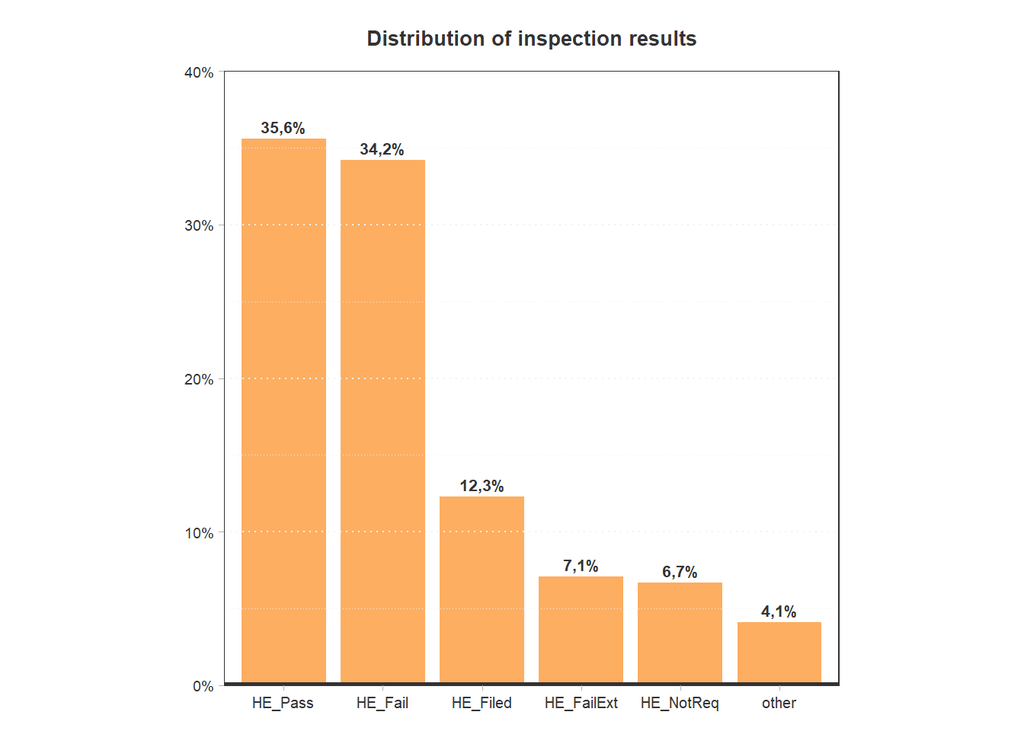

```r
df_count_results <- df_inspections %>%
  count(result) %>%
  arrange(desc(n)) %>%
  mutate(perc=round(n/sum(n), 3)) %>%
  mutate(result = ifelse(perc < 0.04, "other", result)) %>%
  group_by(result) %>%
  summarise(
    n = sum(n),
    perc = round(sum(perc), 3)
  ) %>%
  arrange(desc(n)) %>%
  mutate(result = factor(result, levels = result)) %>%
  perc_adjuster()

plot_single_count(
  df_count_results,
  "result",
  title="Distribution of inspection results",
  m=c(20, 5, 10, 5)
  )
```

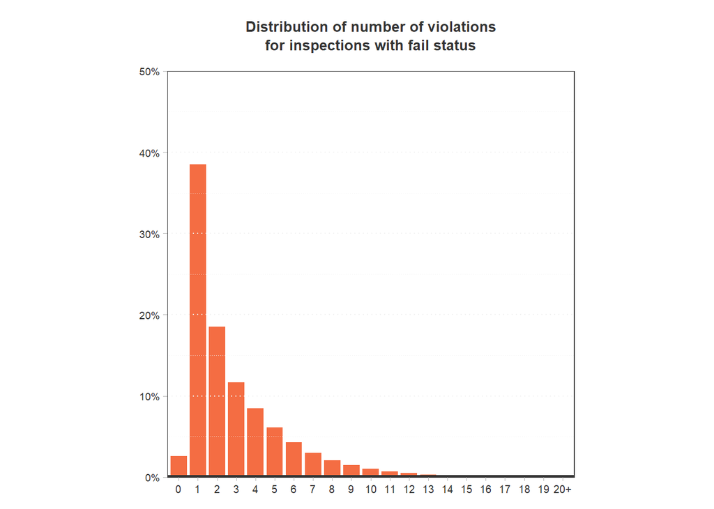

```r
df_inspections_fail <- df_inspections %>%
  filter(result=="HE_Fail")

df_inspections_fail <- df_inspections_fail %>%
  mutate(total_fail_bins = ifelse(total_fail>=20, "20+", total_fail)) %>%
  mutate(critical_fail_bins = ifelse(critical_fail>=12, "12+", critical_fail)) %>%
  mutate(moderate_fail_bins = ifelse(moderate_fail>=12, "12+", moderate_fail)) %>%
  mutate(minor_fail_bins = ifelse(minor_fail>=12, "12+", minor_fail))

bins_levels <- c(c(0:19), "20+")

count_total_fail <- df_inspections_fail %>%
  count(total_fail_bins) %>%
  mutate(total_fail_bins = factor(total_fail_bins, levels = bins_levels)) %>%
  mutate(perc=round(n/sum(n), 3)) %>%
  perc_adjuster()

plot_single_count(
  count_total_fail,
  fill="#f46d43",
  "total_fail_bins",
  title="Distribution of number of violations",
  subtitle="for inspections with fail status",
  same_size = TRUE,
  m=c(20, 5, 10, 5),
  include_labels = FALSE
  )
```

Now, let’s analyze the inspection dataset for potential issues.

```r
df_inspections %>%
  group_by(businessname, legalowner, address, resultdttm, result) %>%
  summarise(count = n()) %>%
  arrange(desc(count)) %>%
  head(5) %>%
  format_table() %>%
  scroll_box(width = "100%")
```

| businessname | legalowner | address | resultdttm | result | count |
| --- | --- | --- | --- | --- | --- |
| Dewey Sq. Farmers Market | NA | 0 DEWEY SQ | 2012-12-30 05:00:00 | HE_NotReq | 14 |
| SOWA Sundays | NICOSIA MARIO TS | 536 HARRISON AV | 2012-12-30 05:00:00 | HE_NotReq | 13 |
| SOWA Sundays | NICOSIA MARIO TS | 536 HARRISON AV | NA | HE_Pass | 13 |
| Winter Festival @ City Hall | NA | 1 CITY HALL PZ | 2022-09-14 17:47:39 | HE_NotReq | 13 |
| Copley Sq. Farmers Market | NA | 0 BOYLSTON ST | 2012-12-30 05:00:00 | HE_NotReq | 11 |

We noticed some inspections appear repeated. Ideally, we should count each inspection only once. Most repeated entries have a result of “HE_NotReq,” meaning the inspection was not performed. These entries often have null values in other fields, so we’ll remove them and regroup to check the impact.

```r
df_inspections %>%
  group_by(businessname, legalowner, address, resultdttm, result) %>%
  filter(result!="HE_NotReq") %>%
  summarise(count = n()) %>%
  arrange(desc(count)) %>%
  filter(count>1) %>%
  head(10) %>%
  format_table()
```

| businessname | legalowner | address | resultdttm | result | count |
| --- | --- | --- | --- | --- | --- |
| SOWA Sundays | NICOSIA MARIO TS | 536 HARRISON AV | NA | HE_Pass | 13 |
| Downtown Crossing Holiday Market | NA | 0 SUMMER ST | NA | HE_Pass | 8 |
| Yamato II | NA | 545 BOYLSTON ST | 2024-01-24 19:05:48 | HE_FailExt | 8 |
| Blue Yama | NA | 418 MARKET ST | 2021-04-13 15:39:33 | HE_Fail | 7 |
| CAPPY’S PIZZA & SUBS | NA | 82 WESTLAND AV | 2024-09-06 15:35:58 | HE_Hearing | 7 |
| Chilacates | Reyes Pedro owner | 222 AMORY ST | 2021-04-20 16:41:00 | HE_Hearing | 7 |
| Cobblestones | NA | 30 CHARLES ST | 2024-02-14 15:31:17 | HE_FailExt | 7 |
| Diallo’s Halal Meat | BOUBACAR DIALLO MARIAMA D .BARRY DIALLO | 11 ERIE ST | 2021-03-19 19:26:42 | HE_TSOP | 7 |
| FIG’S | ZUROMSKIS J MICHAEL TRSTS | 42 CHARLES ST | 2022-12-13 17:37:20 | HE_Hearing | 7 |
| FIG’S | ZUROMSKIS J MICHAEL TRSTS | 42 CHARLES ST | 2024-01-09 18:11:24 | HE_FailExt | 7 |

Next, we’ll verify that no inspections are recorded with different results on the same inspection date (ignoring null resultdttm values). In the future, we can estimate dates based on the violation record number to maintain proper order.

```r
df_inspections %>%
  group_by(businessname, legalowner, address, resultdttm, result) %>%
  filter(result!="HE_NotReq") %>%
  summarise(count = n()) %>%
  ungroup() %>%
  arrange(desc(count)) %>%
  filter(!(is.na(resultdttm))) %>%
  group_by(businessname, legalowner, address, resultdttm) %>%
  summarise(count = n()) %>%
  ungroup() %>%
  arrange(desc(count)) %>%
  head(10) %>%
  format_table()
```

| businessname | legalowner | address | resultdttm | count |
| --- | --- | --- | --- | --- |
| AMRHEIN’S | MULREY JOSEPH | 80 W BROADWAY | 2007-01-23 05:00:00 | 2 |
| Bombay Club | NA | 300 FANEUIL HALL MARKET PL | 2007-05-21 04:00:00 | 2 |
| Brownstone | AGORIANITIS GEORGE ETAL | 109 DARTMOUTH ST | 2006-12-20 05:00:00 | 2 |
| Dollar City | NA | 443 W BROADWAY | 2006-11-21 05:00:00 | 2 |
| King’s Chinese Food | NA | 303 W BROADWAY | 2007-02-13 05:00:00 | 2 |
| NICOLE’S SEASIDE CAFE | GEORGE A. SILVA | 165 WILLIAM J DAY BL | 2007-08-07 04:00:00 | 2 |
| 100 Federal Market & Barista- 10th Floor | ONE HUNDRED FEDERAL ST LPS | 100 FEDERAL ST | 2023-08-23 12:28:50 | 1 |
| 100 Federal Market & Barista- 10th Floor | ONE HUNDRED FEDERAL ST LPS | 100 FEDERAL ST | 2024-03-11 16:18:18 | 1 |
| 100 Federal Market & Barista- 11th Floor | ONE HUNDRED FEDERAL ST LPS | 100 FEDERAL ST | 2021-11-03 14:47:15 | 1 |
| 100 Federal Market & Barista- 11th Floor | ONE HUNDRED FEDERAL ST LPS | 100 FEDERAL ST | 2022-03-10 16:33:56 | 1 |

We found six inspections from 2006-2007 with different results recorded for the same date. This likely reflects early data entry issues before inspectors got used to the process. We’ll manually review and choose the most accurate result.

```r
df_inspections %>%
  filter(
    businessname == "AMRHEIN'S" &
    resultdttm == "2007-01-23 05:00:00"
    )
```

```r
df_inspections %>%
  filter(
    businessname == "Bombay Club" &
    resultdttm == "2007-05-21 04:00:00"
    )
```

```r
df_inspections %>%
  filter(
    businessname == "Brownstone" &
    resultdttm == "2006-12-20 05:00:00"
    )
```

```r
df_inspections %>%
  filter(
    businessname == "Dollar City" &
    resultdttm == "2006-11-21 05:00:00"
    )
```

```r
df_inspections %>%
  filter(
    businessname == "King's Chinese Food" &
    resultdttm == "2007-02-13 05:00:00"
    )
```

```r
df_inspections %>%
  filter(
    businessname == "NICOLE'S SEASIDE CAFE" &
    resultdttm == "2007-08-07 04:00:00"
    )
```

**Next steps**

Assign a consistent ID to inspection groups that are follow-ups, allowing us to distinguish between regular and follow-up inspections.

**Annex**

I discovered a few more insights related to geospatial data, which will be included in the blog post.

# Get basemap

```r
bbox_boston <- c(
  "left" = -71.195,
  "bottom" = 42.230,
  "right" = -70.955,
  "top" = 42.400
)

basemap_boston <- get_stadiamap(bbox=bbox_boston,
                              maptype="stamen_terrain",
                              zoom=12)
```

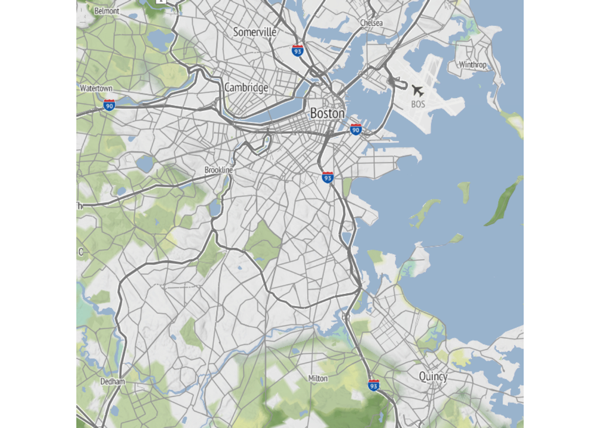

```r
ggmap(basemap_boston) +
  theme_void()
```